# Práctica: Optimización de Redes Neuronales

### Asignatura: Inteligencia Artificial

Integrante: Xavier Caceres

Fecha:3 de Diciembre del 2025

# Fundamentos de Machine Learning y Redes Neuronales

## 1. ¿Qué es Machine Learning (Aprendizaje Automático)?

El Machine Learning es una rama de la Inteligencia Artificial que permite a las computadoras aprender de los datos y mejorar su rendimiento sin ser programadas explícitamente para cada regla.

En lugar de escribir código que diga: *"Si la glucosa es > 100, entonces es paciente"*, alimentamos al modelo con miles de ejemplos médicos y dejamos que el algoritmo encuentre ese patrón por sí mismo.

### Tipos Principales de Aprendizaje

- **Aprendizaje Supervisado (Supervised Learning):** El modelo se entrena con datos que ya tienen la respuesta correcta (etiquetas).
  - *Ejemplo:* Tu dataset `dataR2`, donde ya sabíamos quién era "Sano" (1) y quién "Paciente" (0).
- **Aprendizaje No Supervisado:** El modelo busca patrones en datos sin etiquetas (agrupamiento o clustering).
- **Aprendizaje por Refuerzo:** El modelo aprende a base de prueba y error (premios y castigos).

## 2. El Flujo de Trabajo en Ciencia de Datos

Para que un modelo funcione, seguimos una "Pipeline" estricta:

1. **Preprocesamiento (Preprocessing):** Limpieza de datos. Las máquinas entienden números, no texto.
   - *Imputación:* Rellenar datos faltantes.
   - *Escalado (Scaling):* Poner todas las variables (Edad, Insulina, Glucosa) en la misma escala (ej. Standard Scaler) para que una variable grande no domine a las pequeñas.
2. **División de Datos (Train/Test Split):**
   - **Train (80%):** Datos para que el modelo estudie.
   - **Test (20%):** Datos que el modelo nunca ha visto, usados para el examen final.
3. **Entrenamiento (Fit):** El proceso matemático de ajustar los pesos.
4. **Predicción y Evaluación:** Medir qué tan bien funciona el modelo con métricas matemáticas.

## 3. Redes Neuronales Artificiales (ANN)

Son modelos inspirados en el cerebro humano, diseñados para reconocer patrones complejos.

### Arquitectura Básica

1. **Capa de Entrada (Input Layer):** Recibe los datos crudos. Tiene tantas neuronas como variables tengas (en tu caso, 9 variables: Age, BMI, Glucose, etc.).
2. **Capas Ocultas (Hidden Layers):** Donde ocurre la "magia". Procesan la información combinando las entradas.
   - *Dense Layer:* Cada neurona se conecta con todas las de la capa anterior.
3. **Capa de Salida (Output Layer):** Entrega el resultado final.
   - Para clasificación binaria (Sano vs Paciente), suele tener **1 sola neurona**.

### Conceptos Clave del Entrenamiento

- **Neurona:** Unidad básica de procesamiento.
- **Pesos (Weights):** La importancia que la red le da a cada conexión. Si el "BMI" es muy importante para el diagnóstico, su peso será mayor.
- **Sesgo (Bias):** Un valor extra que ayuda a la neurona a activarse (similar a la ordenada al origen en una recta).

## 4. Funciones de Activación

Deciden si una neurona debe "dispararse" o no. Sin ellas, la red sería una simple multiplicación lineal.

- **ReLU (Rectified Linear Unit):** Se usa en capas ocultas. Convierte los valores negativos a cero y deja pasar los positivos. Es muy rápida y eficiente.
- **Sigmoid:** Se usa en la **capa de salida** para problemas binarios. Aplasta cualquier número para que quede entre **0 y 1**.
  - Resultado cercano a 0 $\rightarrow$ Clase 0 (Paciente).
  - Resultado cercano a 1 $\rightarrow$ Clase 1 (Sano).

## 5. Optimización y Control de Errores

### ¿Cómo aprende la red? (Backpropagation)

La red hace una predicción, compara con la realidad, calcula el error y "retrocede" ajustando los pesos para equivocarse menos la próxima vez.

- **Loss Function (Función de Pérdida):** Mide el error. En tu caso usamos `binary_crossentropy` (ideal para Sí/No).
- **Optimizer:** El algoritmo que decide *cómo* ajustar los pesos.
  - *Adam:* Muy popular, ajusta la velocidad de aprendizaje automáticamente.
  - *RMSprop:* Bueno para datos ruidosos.
- **Epochs (Épocas):** Cuántas veces la red ve el dataset completo. (Pocas épocas = no aprende; muchas épocas = memoriza).
- **Batch Size:** Cuántos datos procesa antes de actualizar sus pesos.

### Evitando el "Memorismo" (Overfitting)

Si la red se aprende los datos de memoria, fallará con pacientes nuevos.

- **Dropout:** Es una técnica donde "apagamos" aleatoriamente un porcentaje de neuronas (ej. 35%) en cada paso. Esto obliga a la red a no depender de neuronas específicas y ser más robusta.

## 6. Métricas de Evaluación

- **Accuracy (Exactitud):** Porcentaje total de aciertos. (ej. 80% significa que de 100 pacientes, diagnosticó bien a 80).
- **Precision:** De todos los que la red dijo "Es Sano", ¿cuántos lo eran realmente? (Evita Falsos Positivos).
- **Recall (Sensibilidad):** De todos los que *realmente* eran "Sanos", ¿a cuántos detectó la red? (Evita Falsos Negativos).
- **F1-Score:** Un promedio armónico entre Precision y Recall. Es la mejor métrica si tienes datos desbalanceados.
- **Matriz de Confusión:** Tabla que muestra:
  - *Verdaderos Positivos (TP)*
  - *Verdaderos Negativos (TN)*
  - *Falsos Positivos (FP - Error Tipo I)*
  - *Falsos Negativos (FN - Error Tipo II)*

### Fase 1: Preparación de datos

```python
pip install scikeras
```

```python
pip install tensorflow
```

```python
import pandas as pd  # Para manipulación de datos
import numpy as np  # Para operaciones numéricas
import matplotlib.pyplot as plt  # Para graficar
import seaborn as sns  # Para visualización

from time import time
from datetime import datetime, timedelta

from sklearn.impute import SimpleImputer  # Para imputación de valores faltantes
from sklearn.preprocessing import OneHotEncoder, StandardScaler, OrdinalEncoder, MinMaxScaler  # Para preprocesamiento de datos
from sklearn.compose import make_column_transformer, ColumnTransformer  # Para transformar columnas
from sklearn.pipeline import Pipeline  # Para encadenar transformaciones y modelos
import pickle  # Para guardar y cargar modelos
import copy

from sklearn.model_selection import train_test_split  # Para dividir el dataset en entrenamiento y prueba
from scikeras.wrappers import KerasClassifier, KerasRegressor  # Para utilizar Keras con scikit-learn
from sklearn.model_selection import cross_val_score  # Para validación cruzada
from sklearn.model_selection import StratifiedKFold  # Para particionar en folds estratificados
from sklearn.model_selection import ShuffleSplit  # Para dividir de forma aleatoria
from sklearn.model_selection import GridSearchCV  # Para búsqueda de hiperparámetros
from keras.layers import Dropout  # Para regularización de la red neuronal

import keras
from keras.layers import Dense  # Para crear capas densas en redes neuronales
from keras.models import Sequential  # Para construir el modelo secuencial
from keras.models import model_from_json  # Para cargar modelos desde un archivo JSON
from keras.models import load_model  # Para cargar modelos preentrenados

from sklearn import metrics  # Para métricas de rendimiento
from sklearn.metrics import confusion_matrix  # Para la matriz de confusión
from sklearn.metrics import accuracy_score  # Para precisión
from sklearn.metrics import precision_score  # Para precisión
from sklearn.metrics import recall_score  # Para recall
from sklearn.metrics import f1_score  # Para la puntuación F1

from sklearn import set_config  # Para visualizar el pipeline configurado

print("Módulos y clases importados")
```

```
Módulos y clases importados
```

# Carga y descripción del dataset

**Nombre del dataset:** Breast Cancer Coimbra Data Set (dataR2).  
**Enlace:** [UCI Machine Learning Repository - Breast Cancer Coimbra](https://archive.ics.uci.edu/ml/datasets/Breast+Cancer+Coimbra)

**Descripción general:** Este conjunto de datos clasifica a los participantes en dos grupos (pacientes y controles sanos) basándose en análisis de sangre rutinarios y datos antropométricos. Se utilizan biomarcadores como la insulina, glucosa, leptina y adiponectina para predecir la presencia de carcinoma de mama.

- **Número de Variables (o atributos):** 10 (9 predictoras + 1 etiqueta).
- **Número de instancias (Pacientes):** 116.
- **Salida:** `Classification`
  - **1:** Control Saludable (Sano).
  - **2:** Paciente (Patología detectada). *(Nota: Para el entrenamiento de la red neuronal, la clase '2' fue transformada a '0').*

### Descripción de Variables y Técnicas de Transformación

A continuación se describen las variables del dataset **Breast Cancer Coimbra (dataR2)** y las técnicas aplicadas en el preprocesamiento:

| Id | Variable | Descripción breve | Tipo | Técnica de transformación |
| --- | --- | --- | --- | --- |
| 1 | **Age** | Edad del paciente (años). | Numérica (Discreta) | Estandarización (StandardScaler) |
| 2 | **BMI** | Índice de Masa Corporal (kg/m²). | Numérica (Continua) | Estandarización (StandardScaler) |
| 3 | **Glucose** | Nivel de glucosa en sangre (mg/dL). | Numérica (Discreta) | Estandarización (StandardScaler) |
| 4 | **Insulin** | Nivel de insulina (µU/mL). | Numérica (Continua) | Estandarización (StandardScaler) |
| 5 | **HOMA** | Modelo de evaluación de homeostasis (resistencia a insulina). | Numérica (Continua) | Estandarización (StandardScaler) |
| 6 | **Leptin** | Hormona leptina (ng/mL). | Numérica (Continua) | Estandarización (StandardScaler) |
| 7 | **Adiponectin** | Proteína adiponectina (µg/mL). | Numérica (Continua) | Estandarización (StandardScaler) |
| 8 | **Resistin** | Hormona resistina (ng/mL). | Numérica (Continua) | Estandarización (StandardScaler) |
| 9 | **MCP.1** | Proteína quimioatrayente de monocitos (pg/dL). | Numérica (Continua) | Estandarización (StandardScaler) |
| 10 | **Classification** | Diagnóstico (1=Sano, 2=Paciente). | Categórica (Nominal/Binaria) | Reemplazo simple (Label Encoding: 2→0, 1→1) |

```python
import pandas as pd

# 1. Definición de nombres de variables (Estilo manual como en tu ejemplo)
nombresVariables = ['Age', 'BMI', 'Glucose', 'Insulin', 'HOMA', 'Leptin',
                    'Adiponectin', 'Resistin', 'MCP.1', 'Classification']

# 2. Cargar el dataframe desde el archivo local
# Nota: dataR2.csv usa comas (sep=',') y ya tiene una fila de encabezado.
# Por eso no pasamos 'names=nombresVariables' dentro de read_csv para evitar duplicar la cabecera.
dataframe = pd.read_csv('dataR2.csv')

# 3. Descripción del dataset (Prints solicitados)
print('cantidad de observaciones (pacientes): ', dataframe.shape[0])
print('cantidad de variables: ', dataframe.shape[1])
print(dataframe.shape)

# 4. Visualización
dataframe.head()
```

```
cantidad de observaciones (pacientes):  116
cantidad de variables:  10
(116, 10)
```

|  | Age | BMI | Glucose | Insulin | HOMA | Leptin | Adiponectin | Resistin | MCP.1 | Classification |
| --- | --- | --- | --- | --- | --- | --- | --- | --- | --- | --- |
| 0 | 48 | 23.500000 | 70 | 2.707 | 0.467409 | 8.8071 | 9.702400 | 7.99585 | 417.114 | 1 |
| 1 | 83 | 20.690495 | 92 | 3.115 | 0.706897 | 8.8438 | 5.429285 | 4.06405 | 468.786 | 1 |
| 2 | 82 | 23.124670 | 91 | 4.498 | 1.009651 | 17.9393 | 22.432040 | 9.27715 | 554.697 | 1 |
| 3 | 68 | 21.367521 | 77 | 3.226 | 0.612725 | 9.8827 | 7.169560 | 12.76600 | 928.220 | 1 |
| 4 | 86 | 21.111111 | 92 | 3.549 | 0.805386 | 6.6994 | 4.819240 | 10.57635 | 773.920 | 1 |

## Formato a la variable de salida

```python
import pandas as pd

# Asumiendo que el dataframe ya fue cargado previamente
# dataframe = pd.read_csv('dataR2.csv')

# Formato a la variable de salida
# Se modifica la variable de salida (de estudio): Classification.
# Es mejor tener la salida en formato binario (0 y 1) cuando hay dos clases.

# Reemplazamos el valor 2 por 0.
# Ahora: 1 = Grupo 1, 0 = Grupo 2 (antes era 2)
dataframe['Classification'] = dataframe['Classification'].replace(2, 0)

# Verificación
print(dataframe['Classification'].unique()) # Debería mostrar [1 0]
dataframe.head()
```

```
[1 0]
```

|  | Age | BMI | Glucose | Insulin | HOMA | Leptin | Adiponectin | Resistin | MCP.1 | Classification |
| --- | --- | --- | --- | --- | --- | --- | --- | --- | --- | --- |
| 0 | 48 | 23.500000 | 70 | 2.707 | 0.467409 | 8.8071 | 9.702400 | 7.99585 | 417.114 | 1 |
| 1 | 83 | 20.690495 | 92 | 3.115 | 0.706897 | 8.8438 | 5.429285 | 4.06405 | 468.786 | 1 |
| 2 | 82 | 23.124670 | 91 | 4.498 | 1.009651 | 17.9393 | 22.432040 | 9.27715 | 554.697 | 1 |
| 3 | 68 | 21.367521 | 77 | 3.226 | 0.612725 | 9.8827 | 7.169560 | 12.76600 | 928.220 | 1 |
| 4 | 86 | 21.111111 | 92 | 3.549 | 0.805386 | 6.6994 | 4.819240 | 10.57635 | 773.920 | 1 |

## Eliminación de variables y separación de variable de salida

```python
import pandas as pd

# Asumiendo que ya cargaste los datos
# dataframe = pd.read_csv('dataR2.csv')

# 1. Separar la Variable de Salida (Y)
Y = dataframe['Classification']

# 2. Separar las Variables Independientes (X)
# Eliminamos la variable objetivo del dataframe original
dataframe = dataframe.drop(['Classification'], axis=1)

# Asignamos el resultado a 'X' por convención estándar
X = dataframe

# 3. Verificación
print("Dimensiones de X (Variables independientes):", X.shape)
print("Dimensiones de Y (Variable dependiente):", Y.shape)

# Mostrar las primeras filas
X.head()
```

```
Dimensiones de X (Variables independientes): (116, 9)
Dimensiones de Y (Variable dependiente): (116,)
```

|  | Age | BMI | Glucose | Insulin | HOMA | Leptin | Adiponectin | Resistin | MCP.1 |
| --- | --- | --- | --- | --- | --- | --- | --- | --- | --- |
| 0 | 48 | 23.500000 | 70 | 2.707 | 0.467409 | 8.8071 | 9.702400 | 7.99585 | 417.114 |
| 1 | 83 | 20.690495 | 92 | 3.115 | 0.706897 | 8.8438 | 5.429285 | 4.06405 | 468.786 |
| 2 | 82 | 23.124670 | 91 | 4.498 | 1.009651 | 17.9393 | 22.432040 | 9.27715 | 554.697 |
| 3 | 68 | 21.367521 | 77 | 3.226 | 0.612725 | 9.8827 | 7.169560 | 12.76600 | 928.220 |
| 4 | 86 | 21.111111 | 92 | 3.549 | 0.805386 | 6.6994 | 4.819240 | 10.57635 | 773.920 |

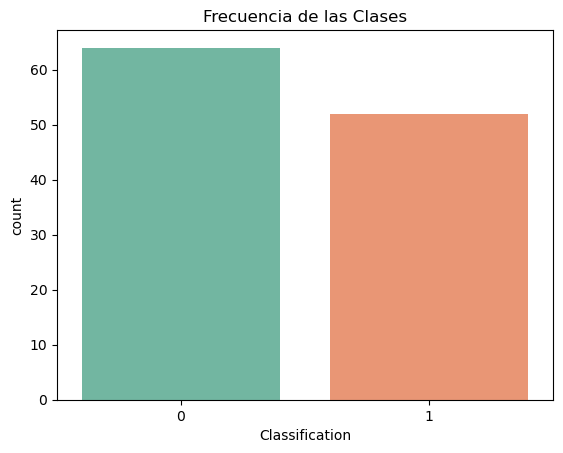

```python
import seaborn as sns
import matplotlib.pyplot as plt

# Se genera una figura de frecuencia de clase con colores diferentes
# Usamos 'palette' para asignar esquemas de colores (ej: 'Set2', 'viridis', 'coolwarm')
# Agregamos hue=Y y legend=False para evitar advertencias en versiones nuevas de Seaborn
sns.countplot(x=Y, hue=Y, palette='Set2', legend=False)

plt.title('Frecuencia de las Clases')
plt.show()
```

## Análisis de variables categóricas

```python
# Determinación de tipos de variables para dataR2.csv
# Como todas son numéricas, las listas categóricas quedan vacías.

categorical_ordinal_features = []

categorical_nominal_features = []

numeric_features = ['Age', 'BMI', 'Glucose', 'Insulin', 'HOMA', 'Leptin',
                    'Adiponectin', 'Resistin', 'MCP.1']

def analisisVariables(dataframe, categorical_ordinal_features, categorical_nominal_features):
    # Se asume que 'dataframe' es X (las variables independientes sin la columna Classification)
    cantidadTotalVariables = len(dataframe.columns)
    print('Cantidad de variables antes de transformación de variables: ', cantidadTotalVariables)

    cantidadVariablesNominales = len(categorical_nominal_features)
    cantidadVariablesBinarias = 0

    for variable in categorical_nominal_features:
        cantidadCategorias = dataframe[variable].nunique()
        cantidadVariablesBinarias = cantidadVariablesBinarias + cantidadCategorias
        print('Cantidad de categorías en la variable categórica nominal', variable, ':', cantidadCategorias)

    print('Cantidad de variables binarias que reemplazarán a las variables categóricas nominales: ', cantidadVariablesBinarias)

    cantidadTotalVariablesConTransformacion = cantidadTotalVariables - cantidadVariablesNominales + cantidadVariablesBinarias
    return cantidadTotalVariablesConTransformacion

# Ejecución del análisis
# Nota: Asegúrate de que la variable 'dataframe' aquí contenga solo las variables X (sin Classification)
cantidadTotalVariablesConTransformacion = analisisVariables(dataframe, categorical_ordinal_features, categorical_nominal_features)
print('Cantidad de variables que habrá después de la transformación de variables: ', cantidadTotalVariablesConTransformacion)
```

```
Cantidad de variables antes de transformación de variables:  9
Cantidad de variables binarias que reemplazarán a las variables categóricas nominales:  0
Cantidad de variables que habrá después de la transformación de variables:  9
```

En este paso se clasifican las variables del dataset para determinar cómo serán procesadas por el modelo.

- **Definición de Tipos:** Se establecen listas vacías para variables categóricas (`categorical_ordinal` y `categorical_nominal`) y se listan las 9 variables numéricas (`Age`, `BMI`, `Glucose`, etc.), confirmando la naturaleza puramente clínica y cuantitativa del dataset `dataR2`.
- **Cálculo de Dimensionalidad:** La función `analisisVariables` simula el proceso de transformación (como *One-Hot Encoding*) para predecir cuántas columnas tendrá el dataset final.
  - *Resultado:* Dado que no existen variables categóricas que requieran ser convertidas a múltiples columnas binarias, la dimensionalidad se mantiene constante: **9 variables de entrada antes y después del preprocesamiento**.

## Diseño de transformadores

```python
from sklearn.pipeline import Pipeline
from sklearn.compose import ColumnTransformer
from sklearn.preprocessing import OrdinalEncoder, OneHotEncoder, MinMaxScaler, StandardScaler
from sklearn.impute import SimpleImputer

# Definición de transformadores (preprocesadores)

# 1. Preprocesador de variables categóricas a numéricas (ordinales y nominales)
# Nota: Como en dataR2.csv no hay categóricas, estas listas están vacías y el código hará 'passthrough'
categorical_ordinal_transformer = Pipeline(steps=[
    ('ordinal', OrdinalEncoder())])

categorical_nominal_transformer_ConNombres = Pipeline(steps=[
    ('onehot', OneHotEncoder(sparse_output=False, handle_unknown="ignore"))]) # Nota: en versiones nuevas de sklearn se usa sparse_output, en antiguas sparse

preprocesorCategoricoNumericoConNombres = ColumnTransformer(
    transformers=[
        ('catord', categorical_ordinal_transformer, categorical_ordinal_features),
        ('catnom', categorical_nominal_transformer_ConNombres, categorical_nominal_features)
    ], remainder='passthrough', n_jobs=-1)

# 2. Normalización y Scaling: Preprocesador de variables numéricas con transformación MinMaxScaler
minmax_transformer = Pipeline(steps=[
    ('minmax', MinMaxScaler(feature_range=(0, 1)))])

preprocesorMinMax = ColumnTransformer(transformers =[
    ('tranminmax', minmax_transformer, list(range(cantidadTotalVariablesConTransformacion)))
], remainder ='passthrough')

# 3. Estandarización: Preprocesador de variables numéricas con transformación StandardScaler
standardscaler_transformer = Pipeline(steps=[
    ('scaler', StandardScaler(with_mean=True, with_std=True))])

preprocesorStandardScaler = ColumnTransformer(transformers =[
    ('transcaler', standardscaler_transformer, list(range(cantidadTotalVariablesConTransformacion)))
], remainder ='passthrough')

# 4. Preprocesador de variables numéricas con transformación SimpleImputer
# Útil si tuvieras valores vacíos (NaN) en tu tabla.
simpleimputer_transformer = Pipeline(steps=[
    ('simpleimputer', SimpleImputer(strategy='median')) # Otras: strategy='mean', strategy='most_frequent'
])

preprocesorSimpleImputer = ColumnTransformer(transformers =[
    ('transimpleimputer', simpleimputer_transformer, list(range(cantidadTotalVariablesConTransformacion)))
], remainder ='passthrough')
```

## Diseño de pipeline

```python
from sklearn.pipeline import Pipeline

# Construcción de Pipeline con transformadores
# Nota: 'prepcn' se encargará de las conversiones (si las hubiera)
#       'prepstandard' aplicará la estandarización (Z-score) a tus datos numéricos
pipe = Pipeline(steps=[
    ('prepcn', preprocesorCategoricoNumericoConNombres),
    ('prepstandard', preprocesorStandardScaler)
    # ('prepminmax', preprocesorMinMax) # Esta línea está comentada como en tu ejemplo, ya que usualmente se usa uno u otro (Standard o MinMax)
])

print("Pipeline creado exitosamente.")
print(pipe)
```

```
Pipeline creado exitosamente.
Pipeline(steps=[('prepcn',
                 ColumnTransformer(n_jobs=-1, remainder='passthrough',
                                   transformers=[('catord',
                                                  Pipeline(steps=[('ordinal',
                                                                   OrdinalEncoder())]),
                                                  []),
                                                 ('catnom',
                                                  Pipeline(steps=[('onehot',
                                                                   OneHotEncoder(handle_unknown='ignore',
                                                                                 sparse_output=False))]),
                                                  [])])),
                ('prepstandard',
                 ColumnTransformer(remainder='passthrough',
                                   transformers=[('transcaler',
                                                  Pipeline(steps=[('scaler',
                                                                   StandardScaler())]),
                                                  [0, 1, 2, 3, 4, 5, 6, 7,
                                                   8])]))])
```

## Transformación de variables

```python
import copy
import pandas as pd

# Se ejecuta el pipeline
# Creamos una copia profunda para no afectar el dataframe original en memoria
dataframeTransformado = copy.deepcopy(dataframe)

# fit_transform ajusta el pipeline (calcula medias, desviaciones) y transforma los datos
X_Transformado = pipe.fit_transform(dataframeTransformado)
print('********** Pipeline aplicado')

# NOTA: Como en tu dataset dataR2 no hay variables categóricas, saltamos la impresión
# del transformador categórico [1] para evitar errores de índice.
# Si tuvieras variables categóricas, usarías: print(pipe.named_steps['prepcn'].transformers_[1])

# Formación de dataframe transformado con nombres de columnas
cnamesDataset1 = []

# Añadir nombres de ordinales (si hubiera)
if len(categorical_ordinal_features) != 0:
    cnamesDataset1.extend(categorical_ordinal_features)

# Añadir nombres de nominales (si hubiera)
if len(categorical_nominal_features) != 0:
    # nos ubicamos primeramente en el paso "prepcn"
    # luego, en el transformador "catnom" que está en [1] y luego en "onehot"
    cnamesDataset2 = pipe.named_steps['prepcn'].transformers_[1][1].named_steps['onehot'].get_feature_names_out(categorical_nominal_features)
    cnamesDataset1.extend(cnamesDataset2)

# Añadir nombres de numéricas
cnamesDataset3 = numeric_features
cnamesDataset1.extend(cnamesDataset3)

print('********** Cantidad de variables:', len(cnamesDataset1))
print('********** Lista de variables:')
print(cnamesDataset1)

# Crear el DataFrame con los datos transformados y las columnas correctas
dataframeTransformado = pd.DataFrame(data=X_Transformado, columns=cnamesDataset1)

# Guardar el dataset sin etiquetas como csv
dataframeTransformado.to_csv("DatasetTransformadoSinEtiquetas.csv", sep=";", index=False)

# Se agrega la variable de salida (etiquetas) al final
# Importante: Aseguramos que los índices coincidan
dataframeTransformado = pd.concat([dataframeTransformado, Y.reset_index(drop=True)], axis=1)

# Guardar el dataset con etiquetas como csv
dataframeTransformado.to_csv("DatasetTransformadoConEtiquetas.csv", sep=";", index=False)

# Mostrar las primeras filas
dataframeTransformado.head()
```

```
********** Pipeline aplicado
********** Cantidad de variables: 9
********** Lista de variables:
['Age', 'BMI', 'Glucose', 'Insulin', 'HOMA', 'Leptin', 'Adiponectin', 'Resistin', 'MCP.1']
```

|  | Age | BMI | Glucose | Insulin | HOMA | Leptin | Adiponectin | Resistin | MCP.1 | Classification |
| --- | --- | --- | --- | --- | --- | --- | --- | --- | --- | --- |
| 0 | -0.579794 | -0.816675 | -1.239222 | -0.728739 | -0.614282 | -0.932334 | -0.070222 | -0.545517 | -0.341251 | 1 |
| 1 | 1.601821 | -1.378751 | -0.258299 | -0.688038 | -0.548240 | -0.930413 | -0.697350 | -0.864214 | -0.191224 | 1 |
| 2 | 1.539489 | -0.891764 | -0.302887 | -0.550073 | -0.464752 | -0.454219 | 1.797998 | -0.441660 | 0.058214 | 1 |
| 3 | 0.666843 | -1.243303 | -0.927110 | -0.676965 | -0.574210 | -0.876021 | -0.441945 | -0.158867 | 1.142718 | 1 |
| 4 | 1.788816 | -1.294601 | -0.258299 | -0.644743 | -0.521081 | -1.042682 | -0.786881 | -0.336352 | 0.694716 | 1 |

```python
import pickle

# Funciones para guardar y cargar un Pipeline o Modelo
def guardarPipeline(pipeline, nombreArchivo):
    # Se abre el archivo en modo escritura binaria ('wb')
    with open(nombreArchivo + '.pickle', 'wb') as handle:
        pickle.dump(pipeline, handle, protocol=pickle.HIGHEST_PROTOCOL)
        print(f"Archivo '{nombreArchivo}.pickle' guardado exitosamente.")

# Ejecución: Guardamos el pipe que creamos anteriormente
guardarPipeline(pipe, 'pipePreprocesadores')
```

```
Archivo 'pipePreprocesadores.pickle' guardado exitosamente.
```

### Fase 2: Entrenamiento base de una red neuronal

```python
import warnings
warnings.filterwarnings("ignore")
```

```python
import pickle
from sklearn import set_config

# Función para cargar el Pipeline
def cargarPipeline(nombreArchivo):
    with open(nombreArchivo + '.pickle', 'rb') as handle:
        pipeline = pickle.load(handle)
    return pipeline

# Definir el nombre del archivo (sin la extensión .pickle, ya que la función la añade)
nombreArchivoPreprocesador = 'pipePreprocesadores'
pipe = None

# Cargar el pipeline
pipe = cargarPipeline(nombreArchivoPreprocesador)

# Verificar la carga
cantidadPasos = len(pipe.steps)
print("Cantidad de pasos:", cantidadPasos)

# Configurar la visualización para ver el diagrama del pipeline
set_config(display='diagram')

# Mostrar el pipeline
pipe
```

```
Cantidad de pasos: 2
```

```
Pipeline(steps=[('prepcn',
                 ColumnTransformer(n_jobs=-1, remainder='passthrough',
                                   transformers=[('catord',
                                                  Pipeline(steps=[('ordinal',
                                                                   OrdinalEncoder())]),
                                                  []),
                                                 ('catnom',
                                                  Pipeline(steps=[('onehot',
                                                                   OneHotEncoder(handle_unknown='ignore',
                                                                                 sparse_output=False))]),
                                                  [])])),
                ('prepstandard',
                 ColumnTransformer(remainder='passthrough',
                                   transformers=[('transcaler',
                                                  Pipeline(steps=[('scaler',
                                                                   StandardScaler())]),
                                                  [0, 1, 2, 3, 4, 5, 6, 7,
                                                   8])]))])
```

```python
from tensorflow.keras.models import load_model

# Funciones para guardar y cargar la Red Neuronal (Arquitectura y Pesos)

def guardarNN(model, nombreArchivo):
    print("Guardando Red Neuronal en Archivo")
    # Se guarda en formato .h5 (Hierarchical Data Format v5)
    model.save(nombreArchivo + '.h5')
    print("Red Neuronal Grabada en Archivo")

def cargarNN(nombreArchivo):
    # Carga el modelo completo (arquitectura + pesos)
    model = load_model(nombreArchivo + '.h5')
    print("Red Neuronal Cargada desde Archivo")
    return model
```

### Gestión de Persistencia del Modelo

En este bloque se definen las funciones utilitarias encargadas del ciclo de vida del modelo (Input/Output):

- **Formato HDF5 (.h5):** Se utiliza este estándar jerárquico para encapsular en un solo archivo todo el modelo: la arquitectura (capas), los pesos aprendidos (sinapsis) y la configuración del optimizador.
- **Reutilización:**
  - `guardarNN`: Permite "congelar" el estado de la red tras el entrenamiento.
  - `cargarNN`: Permite recuperar ese conocimiento instantáneamente en el futuro, facilitando la fase de producción sin necesidad de reentrenar desde cero.

```python
# Creación de la red neuronal
# Se identifica la cantidad de variables para crear la capa de entrada de la red neuronal

# Usamos 'prepstandard' porque es el paso final que procesa todas tus variables numéricas
nombrePrep = 'prepstandard' # Opciones: 'prepcn', 'prepstandard' (o 'prepminmax' si lo hubieras usado)

# Accedemos a la lista de columnas que procesa ese transformador específico
# pipe.named_steps[nombrePrep] -> Accede al ColumnTransformer 'preprocesorStandardScaler'
# .transformers_[0] -> Accede a la primera tupla ('transcaler', pipeline, lista_columnas)
# [2] -> Accede al tercer elemento de la tupla, que es la LISTA DE INDICES DE COLUMNAS
cantidadVariablesIndependientes = len(pipe.named_steps[nombrePrep].transformers_[0][2])

print("\nCantidad de variables después de preprocesamiento: ", cantidadVariablesIndependientes)
```

```
Cantidad de variables después de preprocesamiento:  9
```

**Parámetros y Hiperparámetros de una Red Neuronal**

En el diseño de redes neuronales, es fundamental distinguir entre los valores que la red "aprende" sola y los que nosotros configuramos manualmente.

**1. Parámetros Internos (Entrenables)** Son los valores que la red ajusta automáticamente durante el entrenamiento para minimizar el error (a través del algoritmo de *Backpropagation*).

- **Pesos (Weights):** Determinan la fuerza o importancia de la conexión entre neuronas. Si un biomarcador es crítico para detectar la enfermedad, la red le asignará un peso mayor.
- **Sesgos (Biases):** Funcionan como un umbral de activación, permitiendo que la neurona dispare una señal incluso si las entradas son bajas, ajustando la flexibilidad del modelo.

**2. Hiperparámetros (Configurables)** Son las variables que nosotros definimos antes de iniciar el entrenamiento. Su correcta elección (optimizada en nuestro caso mediante *Grid Search*) es vital para el éxito del modelo.

```python
from tensorflow.keras.models import Sequential
from tensorflow.keras.layers import Dense

# Inicializar el modelo secuencial
model = Sequential()

# La primera capa Dense recibe el numero de variables (9 en tu caso).
# La primera capa tiene 3 neuronas (puedes aumentar esto si el modelo no aprende bien).
# La función de activación es la función rectificadora (Relu).
model.add(Dense(3, input_shape=(cantidadVariablesIndependientes,), activation='relu'))

# La capa de salida tiene 1 neurona.
# La capa de salida debe tener la misma dimensión que la cantidad de salidas que queremos.
# En este caso la salida "Classification" solo requiere un valor: 0 o 1, entonces 1 neurona es suficiente.
# La función de activación es sigmoid para calcular la clasificación en términos de probabilidad (0 a 1).
model.add(Dense(1, activation='sigmoid'))

# Como tenemos dos posibles valores de salida "0 o 1", vamos a escoger que el error lo trate como una clasificación binaria.
model.compile(loss='binary_crossentropy', optimizer='rmsprop', metrics=['acc'])

# Se inserta el modelo como paso final del pipeline
# Nota: Usamos una tupla ('nombre', modelo) para seguir el estándar de sklearn
pipe.steps.append(('modelNN', model))

# Aquí en lugar del clasificador de Red Neuronal podría ser otro modelo como un Random Forest, una SVM, etc.
# También se pudo haber insertado el modelo indicando el índice (el número de paso específico dentro del pipeline)
# pipe.steps.insert(cantidadPasos, ('modelNN', model))

# Se puede eliminar un paso específico del pipeline de la siguiente manera
# pipe.steps.pop(2)

print("Cantidad de pasos: ", len(pipe.steps))

# Mostrar el resumen de la arquitectura de la red neuronal.
# Accedemos al modelo guardado en el pipeline
pipe.named_steps['modelNN'].summary()
```

```
Cantidad de pasos:  3
```

```
Model: "sequential"
```

```
┏━━━━━━━━━━━━━━━━━━━━━━━━━━━━━━━━━┳━━━━━━━━━━━━━━━━━━━━━━━━┳━━━━━━━━━━━━━━━┓
┃ Layer (type)                    ┃ Output Shape           ┃       Param # ┃
┡━━━━━━━━━━━━━━━━━━━━━━━━━━━━━━━━━╇━━━━━━━━━━━━━━━━━━━━━━━━╇━━━━━━━━━━━━━━━┩
│ dense (Dense)                   │ (None, 3)              │            30 │
├─────────────────────────────────┼────────────────────────┼───────────────┤
│ dense_1 (Dense)                 │ (None, 1)              │             4 │
└─────────────────────────────────┴────────────────────────┴───────────────┘
```

```
 Total params: 34 (136.00 B)
```

```
 Trainable params: 34 (136.00 B)
```

```
 Non-trainable params: 0 (0.00 B)
```

## Entrenamiento de la Red Neuronal

```
Datos de Entrenamiento: (92, 9)
Datos de Prueba: (24, 9)
```

```
WARNING:absl:You are saving your model as an HDF5 file via `model.save()` or `keras.saving.save_model(model)`. This file format is considered legacy. We recommend using instead the native Keras format, e.g. `model.save('my_model.keras')` or `keras.saving.save_model(model, 'my_model.keras')`.
```

```
Modelo base entrenado
Guardando Red Neuronal en Archivo
Red Neuronal Grabada en Archivo
Modelo Base Guardado
```

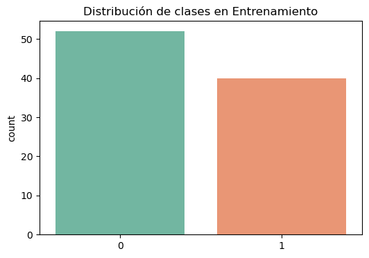

```python
from sklearn.model_selection import train_test_split
import copy
import matplotlib.pyplot as plt
import seaborn as sns

# Preparación de datos
Yval = Y.values
X = copy.deepcopy(dataframe)

# Separación en conjuntos de entrenamiento (Train) y prueba (Test)
X_train, X_test, y_train, y_test = train_test_split(X, Yval, test_size=0.2, random_state=42)

print("Datos de Entrenamiento:", X_train.shape)
print("Datos de Prueba:", X_test.shape)

# Entrenamiento de la Red Neuronal
# Aumentamos epochs a 50 para mejor aprendizaje en datos médicos
pipe.fit(X_train, y_train, modelNN__epochs=50, modelNN__batch_size=10, modelNN__verbose=0)
print('Modelo base entrenado')

# Guardar el modelo
# (La advertencia sobre .h5 aparecerá aquí, pero es inofensiva)
guardarNN(model, 'modeloRedNeuronalBase')
print('Modelo Base Guardado')

# Visualizar con colores diferentes
plt.figure(figsize=(6, 4))
# Agregamos hue=y_train y palette='Set2' para dar color
sns.countplot(x=y_train, hue=y_train, palette='Set2', legend=False)
plt.title("Distribución de clases en Entrenamiento")
plt.show()
```

## Predicción con modelo base y evaluación de calidad: MAE, MSE, RMSE, Accuracy, Precision, Recall y F1

```python
from sklearn.metrics import mean_absolute_error, mean_squared_error, accuracy_score, precision_score, recall_score, f1_score
import numpy as np
import pandas as pd

# 1. Realizar predicciones con el modelo base
# pipe.predict pasa los datos por el escalador y luego por la red neuronal
# La salida son probabilidades (0.1, 0.9, etc.), así que usamos > 0.5 para convertir a 0 o 1
y_pred_probs = pipe.predict(X_test)
y_pred = (y_pred_probs > 0.5).astype("int32")

# De 2D a 1D (aplanar el array para que tenga el mismo formato que y_test)
y_pred = y_pred.flatten()

# 2. Crear un DataFrame para comparar Real vs Predicción visualmente
dataframeFinal = pd.DataFrame({'real': y_test, 'predicción': y_pred})
np.set_printoptions(formatter={'float': lambda X: "{0:0.0f}".format(X)})

print("Primeras 20 predicciones vs realidad:")
print(dataframeFinal.head(20))

# 3. Evaluación de métricas de calidad
mae = mean_absolute_error(y_test, y_pred)
mse = mean_squared_error(y_test, y_pred)
rmse = np.sqrt(mse)
accuracy = accuracy_score(y_test, y_pred)
precision = precision_score(y_test, y_pred)
recall = recall_score(y_test, y_pred)
f1 = f1_score(y_test, y_pred)

# Mostrar resultados
print("\n********** Evaluación de Calidad del Modelo **********")
print(f"MAE (Error Absoluto Medio):       {mae:.4f}")
print(f"MSE (Error Cuadrático Medio):     {mse:.4f}")
print(f"RMSE (Raíz de MSE):               {rmse:.4f}")
print("-" * 40)
print(f"Accuracy (Exactitud):             {accuracy:.4f}")
print(f"Precision (Precisión):            {precision:.4f}")
print(f"Recall (Sensibilidad):            {recall:.4f}")
print(f"F1 Score (Promedio armónico):     {f1:.4f}")
```

```
1/1 ━━━━━━━━━━━━━━━━━━━━ 0s 92ms/step
Primeras 20 predicciones vs realidad:
    real  predicción
0      0           0
1      1           1
2      1           1
3      1           1
4      1           1
5      1           1
6      0           0
7      1           1
8      0           0
9      1           0
10     1           1
11     1           1
12     0           0
13     0           0
14     1           1
15     1           1
16     0           0
17     0           0
18     0           0
19     0           0

********** Evaluación de Calidad del Modelo **********
MAE (Error Absoluto Medio):       0.0417
MSE (Error Cuadrático Medio):     0.0417
RMSE (Raíz de MSE):               0.2041
----------------------------------------
Accuracy (Exactitud):             0.9583
Precision (Precisión):            1.0000
Recall (Sensibilidad):            0.9167
F1 Score (Promedio armónico):     0.9565
```

## Fase 3: Optimización del modelo de red neuronal (Fine Tuning)

### Ajuste Fino (Fine Tuning) y Estrategia de Optimización

Tras establecer una línea base con el modelo inicial, entramos en la etapa crítica del desarrollo: la **optimización de hiperparámetros**. El objetivo no es solo lograr que el modelo "aprenda", sino que generalice de manera óptima ante nuevos casos médicos, maximizando la precisión y minimizando los falsos negativos.

Para lograr esto, abandonamos el enfoque de prueba y error manual y adoptamos una metodología científica y exhaustiva:

#### 1. Búsqueda Sistemática (Grid Search)

Utilizamos la técnica de **Grid Search**, que explora exhaustivamente una "malla" de combinaciones posibles de parámetros. En lugar de adivinar qué configuración funciona mejor, el algoritmo entrena y evalúa el modelo para cada combinación definida, permitiéndonos encontrar matemáticamente la arquitectura ganadora.

#### 2. Validación Cruzada (K-Fold Cross-Validation)

Para asegurar que los resultados no sean producto de la suerte (sesgo por una partición específica de datos), implementamos una validación cruzada con **$K=5$ folds**.

- Esto significa que cada configuración se entrena y prueba 5 veces en subconjuntos de datos diferentes rotativos.
- El resultado final es el **promedio** de estos 5 experimentos, ofreciendo una métrica de rendimiento mucho más robusta y confiable.

#### 3. Parámetros a Optimizar

El proceso se divide en dos etapas lógicas:

- **Paso A - Dinámica de Entrenamiento:** Ajustamos *cómo* aprende la red (Optimizadores como Adam/RMSprop, cantidad de Épocas y tamaño del Batch).
- **Paso B - Arquitectura y Regularización:** Ajustamos la *capacidad* del cerebro (cantidad de neuronas en capas ocultas) e introducimos **Dropout**, una técnica de regularización vital que "apaga" neuronas aleatoriamente para prevenir el memorismo (overfitting) y forzar a la red a aprender patrones más robustos.

## Evaluación de modelo base: promedio de N experimentos

```python
from sklearn import metrics
from sklearn.metrics import accuracy_score, confusion_matrix, precision_score, recall_score, f1_score
import numpy as np

# Cálculo de métricas de error
MAE = metrics.mean_absolute_error(y_test, y_pred)
MSE = metrics.mean_squared_error(y_test, y_pred)
RMSE = np.sqrt(metrics.mean_squared_error(y_test, y_pred))

# Conversión a string para impresión
accuracy = str(accuracy_score(y_test, y_pred))
MAE = str(round(MAE, 4))
MSE = str(round(MSE, 4))
RMSE = str(round(RMSE, 4))

print('Mean Absolute Error (MAE):', MAE)
print('Mean Squared Error (MSE):', MSE)
print('Root Mean Squared Error (RMSE):', RMSE)
print('Accuracy: ' + accuracy)

print('Confusion_matrix:')
# Para mantener la nomenclatura de tu ejemplo
y_test_transformado = y_test
y_pred_transformado = y_pred

# Generar y mostrar matriz
cm = confusion_matrix(y_test_transformado, y_pred_transformado)
print(cm)

# Desglosar la matriz en Verdaderos Negativos, Falsos Positivos, etc.
tn, fp, fn, tp = confusion_matrix(y_test_transformado, y_pred_transformado).ravel()
print("TN:", tn, "FP:", fp, "FN:", fn, "TP:", tp)

# Cálculo de métricas de clasificación
precision = precision_score(y_test_transformado, y_pred_transformado)
precision = str(round(precision, 4))
print('Precision:', precision)

recall = recall_score(y_test_transformado, y_pred_transformado)
recall = str(round(recall, 4))
print('Recall:', recall)

f1 = f1_score(y_test_transformado, y_pred_transformado)
f1 = str(round(f1, 4))
print('F1:', f1)
```

```
Mean Absolute Error (MAE): 0.0417
Mean Squared Error (MSE): 0.0417
Root Mean Squared Error (RMSE): 0.2041
Accuracy: 0.9583333333333334
Confusion_matrix:
[[12  0]
 [ 1 11]]
TN: 12 FP: 0 FN: 1 TP: 11
Precision: 1.0
Recall: 0.9167
F1: 0.9565
```

```python
!pip install scikeras
```

```python
from sklearn.base import BaseEstimator, ClassifierMixin
from tensorflow.keras.models import Sequential
from tensorflow.keras.layers import Dense, Dropout
from sklearn.model_selection import cross_val_score, ShuffleSplit
import copy

# -------------------------------------------------------------------------
# 1. DEFINICIÓN DE LA CLASE
# -------------------------------------------------------------------------
class KerasClassifierPersonalizado(BaseEstimator, ClassifierMixin):
    # Constructor con todos los parámetros que quieras usar en GridSearch
    def __init__(self, epochs=50, batch_size=10, input_dim=9, optimizer='rmsprop',
                 l1=3, l2=0, dr=0.0):
        self.epochs = epochs
        self.batch_size = batch_size
        self.input_dim = input_dim
        self.optimizer = optimizer
        self.l1 = l1 # Neuronas Capa 1
        self.l2 = l2 # Neuronas Capa 2
        self.dr = dr # Dropout
        self.model = None

    def fit(self, X, y):
        self.model = Sequential()
        # Capa 1
        self.model.add(Dense(self.l1, input_shape=(self.input_dim,), activation='relu'))
        if self.dr > 0: self.model.add(Dropout(self.dr))

        # Capa 2 (Solo si l2 > 0)
        if self.l2 > 0:
            self.model.add(Dense(self.l2, activation='relu'))
            if self.dr > 0: self.model.add(Dropout(self.dr))

        # Capa Salida
        self.model.add(Dense(1, activation='sigmoid'))

        self.model.compile(loss='binary_crossentropy', optimizer=self.optimizer, metrics=['accuracy'])
        self.model.fit(X, y, epochs=self.epochs, batch_size=self.batch_size, verbose=0)
        return self

    def predict(self, X):
        pred_probs = self.model.predict(X, verbose=0)
        return (pred_probs > 0.5).astype("int32").flatten()

    def score(self, X, y):
        from sklearn.metrics import accuracy_score
        return accuracy_score(y, self.predict(X))

# -------------------------------------------------------------------------

# Cargar pipeline limpio
pipe = cargarPipeline(nombreArchivoPreprocesador)
X = copy.deepcopy(dataframe)
Yval = Y.values

# Configuración del estimador usando nuestra clase personalizada
# input_dim=cantidadVariablesIndependientes (que era 9)
estimator = KerasClassifierPersonalizado(epochs=50, batch_size=10, input_dim=cantidadVariablesIndependientes)

# Agregamos el estimador al pipeline
pipe.steps.append(('modelNN', estimator))

# Configuración de la validación cruzada
numFolds = 5
kfold = ShuffleSplit(n_splits=numFolds, test_size=0.2, random_state=42)

print(f"Iniciando evaluación con {numFolds} folds...")

# Ejecutar el entrenamiento cruzado (n_jobs=1 para evitar errores en Windows)
cvs = cross_val_score(pipe, X, Yval, cv=kfold, n_jobs=1, error_score="raise")

print("Scores por cada iteración:")
for i in range(numFolds):
    print(f"Fold {i+1}: {cvs[i]:.4f}")

print("-" * 30)
print("Accuracy Promedio del Modelo Base: ", cvs.mean())

accuracyModeloBase = cvs.mean()
```

```
Iniciando evaluación con 5 folds...
Scores por cada iteración:
Fold 1: 0.6250
Fold 2: 0.7083
Fold 3: 0.5417
Fold 4: 0.5000
Fold 5: 0.4167
------------------------------
Accuracy Promedio del Modelo Base:  0.5583333333333333
```

## Optimización - Paso 1. Parámetros de compilación

```python
from sklearn.model_selection import GridSearchCV
from datetime import datetime, timedelta
from time import time
import copy
from sklearn.base import BaseEstimator, ClassifierMixin
from tensorflow.keras.models import Sequential
from tensorflow.keras.layers import Dense
import numpy as np

# 1. Función para medir el tiempo (Tal como en tu ejemplo)
def GetTime(gs_time):
    sec = timedelta(seconds=gs_time)
    d = datetime(1,1,1) + sec
    # d.day-1 porque datetime empieza en día 1
    tiempoTotal = ("%d días: %d horas: %d min: %d seg" % (d.day-1, d.hour, d.minute, d.second))
    return tiempoTotal

# 2. Definición del Wrapper Personalizado (Actualizado para aceptar 'optimizer')
class KerasClassifierPersonalizado(BaseEstimator, ClassifierMixin):
    def __init__(self, epochs=50, batch_size=10, input_dim=9, optimizer='rmsprop'):
        self.epochs = epochs
        self.batch_size = batch_size
        self.input_dim = input_dim
        self.optimizer = optimizer # Nuevo parámetro para optimización
        self.model = None

    def fit(self, X, y):
        self.model = Sequential()
        self.model.add(Dense(3, input_shape=(self.input_dim,), activation='relu'))
        self.model.add(Dense(1, activation='sigmoid'))
        # Usamos self.optimizer aquí para que GridSearch pueda cambiarlo
        self.model.compile(loss='binary_crossentropy', optimizer=self.optimizer, metrics=['accuracy'])

        self.model.fit(X, y, epochs=self.epochs, batch_size=self.batch_size, verbose=0)
        return self

    def predict(self, X):
        pred_probs = self.model.predict(X, verbose=0)
        return (pred_probs > 0.5).astype("int32").flatten()

    def score(self, X, y):
        from sklearn.metrics import accuracy_score
        return accuracy_score(y, self.predict(X))

# 3. Cargar datos y pipeline base
pipe = cargarPipeline(nombreArchivoPreprocesador)
X = copy.deepcopy(dataframe)
Yval = Y.values

# 4. Configurar parámetros para GridSearch
# Nota: He reducido un poco las listas para que no tarde horas en ejecutarse ahora mismo.
# Puedes descomentar las líneas originales si tienes tiempo.
batch_size = [10, 20, 40] # Original: [2,5,10,20,40,80]
epochs = [10, 50, 75]     # Original: [5,10,25,50,75,100]
optimizer = ['rmsprop', 'adam']

parameters = {
    'modelNN__batch_size': batch_size,
    'modelNN__epochs': epochs,
    'modelNN__optimizer': optimizer
}

# 5. Configurar el estimador y añadirlo al pipeline
estimator = KerasClassifierPersonalizado(input_dim=cantidadVariablesIndependientes)
pipe.steps.append(('modelNN', estimator))

# 6. Ejecutar GridSearchCV
# n_jobs=1 es más seguro en Windows para evitar errores. Si tienes Mac/Linux usa -1.
tic = time()
print("Iniciando Grid Search (esto puede tardar)...")

grid_search = GridSearchCV(
    estimator=pipe,
    param_grid=parameters,
    scoring='accuracy',
    cv=5,
    n_jobs=1,
    error_score='raise'
)

grid_result = grid_search.fit(X, Yval)

# 7. Resultados
print("\nMejores parámetros encontrados:")
print(grid_result.best_params_)

gs_time = time() - tic
print('\nTiempo en segundos: ', gs_time)
tiempoTotal = GetTime(gs_time)
print('Tiempo total de ejecución: ', tiempoTotal)

# 8. Detalle de resultados
gs1 = grid_result
print("\nBest Score (Accuracy): %f using %s" % (gs1.best_score_, gs1.best_params_))

print("\nResultados detallados:")
means = gs1.cv_results_['mean_test_score']
stds = gs1.cv_results_['std_test_score']
params = gs1.cv_results_['params']

for mean, stdev, param in zip(means, stds, params):
    print("%f (%f) with: %r" % (mean, stdev, param))
```

```
Iniciando Grid Search (esto puede tardar)...

Mejores parámetros encontrados:
{'modelNN__batch_size': 10, 'modelNN__epochs': 10, 'modelNN__optimizer': 'rmsprop'}

Tiempo en segundos:  337.3689525127411
Tiempo total de ejecución:  0 días: 0 horas: 5 min: 37 seg

Best Score (Accuracy): 0.388406 using {'modelNN__batch_size': 10, 'modelNN__epochs': 10, 'modelNN__optimizer': 'rmsprop'}

Resultados detallados:
0.388406 (0.257041) with: {'modelNN__batch_size': 10, 'modelNN__epochs': 10, 'modelNN__optimizer': 'rmsprop'}
0.268116 (0.136878) with: {'modelNN__batch_size': 10, 'modelNN__epochs': 10, 'modelNN__optimizer': 'adam'}
0.147826 (0.121739) with: {'modelNN__batch_size': 10, 'modelNN__epochs': 50, 'modelNN__optimizer': 'rmsprop'}
0.337681 (0.241364) with: {'modelNN__batch_size': 10, 'modelNN__epochs': 50, 'modelNN__optimizer': 'adam'}
0.336594 (0.144639) with: {'modelNN__batch_size': 10, 'modelNN__epochs': 75, 'modelNN__optimizer': 'rmsprop'}
0.381159 (0.302742) with: {'modelNN__batch_size': 10, 'modelNN__epochs': 75, 'modelNN__optimizer': 'adam'}
0.252174 (0.211931) with: {'modelNN__batch_size': 20, 'modelNN__epochs': 10, 'modelNN__optimizer': 'rmsprop'}
0.335145 (0.123028) with: {'modelNN__batch_size': 20, 'modelNN__epochs': 10, 'modelNN__optimizer': 'adam'}
0.377899 (0.160910) with: {'modelNN__batch_size': 20, 'modelNN__epochs': 50, 'modelNN__optimizer': 'rmsprop'}
0.369928 (0.205011) with: {'modelNN__batch_size': 20, 'modelNN__epochs': 50, 'modelNN__optimizer': 'adam'}
0.336232 (0.208293) with: {'modelNN__batch_size': 20, 'modelNN__epochs': 75, 'modelNN__optimizer': 'rmsprop'}
0.208333 (0.177270) with: {'modelNN__batch_size': 20, 'modelNN__epochs': 75, 'modelNN__optimizer': 'adam'}
0.226087 (0.154087) with: {'modelNN__batch_size': 40, 'modelNN__epochs': 10, 'modelNN__optimizer': 'rmsprop'}
0.282971 (0.118807) with: {'modelNN__batch_size': 40, 'modelNN__epochs': 10, 'modelNN__optimizer': 'adam'}
0.173913 (0.176074) with: {'modelNN__batch_size': 40, 'modelNN__epochs': 50, 'modelNN__optimizer': 'rmsprop'}
0.260507 (0.337016) with: {'modelNN__batch_size': 40, 'modelNN__epochs': 50, 'modelNN__optimizer': 'adam'}
0.234058 (0.098710) with: {'modelNN__batch_size': 40, 'modelNN__epochs': 75, 'modelNN__optimizer': 'rmsprop'}
0.372101 (0.328101) with: {'modelNN__batch_size': 40, 'modelNN__epochs': 75, 'modelNN__optimizer': 'adam'}
```

## Optimización - Paso 2. Densidad de las capas de neuronas y regularización de Dropout

```python
from sklearn.model_selection import GridSearchCV
from tensorflow.keras.models import Sequential
from tensorflow.keras.layers import Dense, Dropout
from sklearn.base import BaseEstimator, ClassifierMixin
from time import time
import copy
import numpy as np

# 1. Actualizamos el Wrapper para aceptar capas dinámicas y Dropout
class KerasClassifierPersonalizado(BaseEstimator, ClassifierMixin):
    def __init__(self, epochs=75, batch_size=10, input_dim=9, optimizer='Adam',
                 l1=64, l2=16, dr=0.0):
        self.epochs = epochs
        self.batch_size = batch_size
        self.input_dim = input_dim
        self.optimizer = optimizer
        # Nuevos parámetros para arquitectura
        self.l1 = l1 # Neuronas capa 1
        self.l2 = l2 # Neuronas capa 2
        self.dr = dr # Tasa de Dropout
        self.model = None

    def fit(self, X, y):
        self.model = Sequential()
        # Capa 1
        self.model.add(Dense(self.l1, input_shape=(self.input_dim,), activation='relu'))
        self.model.add(Dropout(self.dr)) # Dropout capa 1

        # Capa 2 (Nueva capa oculta)
        self.model.add(Dense(self.l2, activation='relu'))
        self.model.add(Dropout(self.dr)) # Dropout capa 2

        # Capa de Salida
        self.model.add(Dense(1, activation='sigmoid'))

        self.model.compile(loss='binary_crossentropy', optimizer=self.optimizer, metrics=['accuracy'])
        self.model.fit(X, y, epochs=self.epochs, batch_size=self.batch_size, verbose=0)
        return self

    def predict(self, X):
        pred_probs = self.model.predict(X, verbose=0)
        return (pred_probs > 0.5).astype("int32").flatten()

    def score(self, X, y):
        from sklearn.metrics import accuracy_score
        return accuracy_score(y, self.predict(X))

# 2. Carga de datos
pipe = cargarPipeline(nombreArchivoPreprocesador)
X = copy.deepcopy(dataframe)
Yval = Y.values

# 3. Definir la malla de parámetros (Grid)
# Reducimos un poco las opciones para que no tarde horas, pero cubrimos rangos clave.
l1_options = [16, 32, 64]        # Original: [4,8,16,32,64,128]
l2_options = [4, 8, 16]          # Original: [4,8,16,32,64,128]
dr_options = [0.0, 0.2, 0.35]    # Original: [0,0.2,0.35,0.5]

parameters = {
    'modelNN__l1': l1_options,
    'modelNN__l2': l2_options,
    'modelNN__dr': dr_options
}

# 4. Configurar el estimador con los mejores parámetros del paso anterior
# (Asumimos epochs=75 y batch=10 del paso anterior, y optimizer='Adam')
estimator = KerasClassifierPersonalizado(
    input_dim=cantidadVariablesIndependientes,
    epochs=75,
    batch_size=10,
    optimizer='Adam'
)

pipe.steps.append(('modelNN', estimator))

# 5. Ejecutar Grid Search
tic = time()
print("Iniciando Grid Search de Arquitectura (esto puede tardar)...")

# n_jobs=1 para estabilidad en Windows
grid_search = GridSearchCV(estimator=pipe, param_grid=parameters, scoring='accuracy', cv=5, n_jobs=1)
grid_result = grid_search.fit(X, Yval)

# 6. Resultados
print("\n********** RESULTADOS **********")
gs_time1 = time() - tic
print('Tiempo en segundos: ', gs_time1)
tiempoTotal = GetTime(gs_time1)
print('Tiempo total: ', tiempoTotal)

gs2 = grid_result
print("Best Score: %f using %s" % (gs2.best_score_, gs2.best_params_))

print("\nResultados detallados:")
means = gs2.cv_results_['mean_test_score']
stds = gs2.cv_results_['std_test_score']
params = gs2.cv_results_['params']

for mean, stdev, param in zip(means, stds, params):
    print("%f (%f) with: %r" % (mean, stdev, param))
```

```
Iniciando Grid Search de Arquitectura (esto puede tardar)...

********** RESULTADOS **********
Tiempo en segundos:  1952.6622049808502
Tiempo total:  0 días: 0 horas: 32 min: 32 seg
Best Score: 0.476449 using {'modelNN__dr': 0.2, 'modelNN__l1': 32, 'modelNN__l2': 16}

Resultados detallados:
0.467391 (0.217609) with: {'modelNN__dr': 0.0, 'modelNN__l1': 16, 'modelNN__l2': 4}
0.405797 (0.110374) with: {'modelNN__dr': 0.0, 'modelNN__l1': 16, 'modelNN__l2': 8}
0.398188 (0.132712) with: {'modelNN__dr': 0.0, 'modelNN__l1': 16, 'modelNN__l2': 16}
0.407609 (0.179068) with: {'modelNN__dr': 0.0, 'modelNN__l1': 32, 'modelNN__l2': 4}
0.423551 (0.153721) with: {'modelNN__dr': 0.0, 'modelNN__l1': 32, 'modelNN__l2': 8}
0.441667 (0.183436) with: {'modelNN__dr': 0.0, 'modelNN__l1': 32, 'modelNN__l2': 16}
0.328986 (0.211594) with: {'modelNN__dr': 0.0, 'modelNN__l1': 64, 'modelNN__l2': 4}
0.398188 (0.165657) with: {'modelNN__dr': 0.0, 'modelNN__l1': 64, 'modelNN__l2': 8}
0.442029 (0.187400) with: {'modelNN__dr': 0.0, 'modelNN__l1': 64, 'modelNN__l2': 16}
0.260870 (0.203931) with: {'modelNN__dr': 0.2, 'modelNN__l1': 16, 'modelNN__l2': 4}
0.267754 (0.187849) with: {'modelNN__dr': 0.2, 'modelNN__l1': 16, 'modelNN__l2': 8}
0.372464 (0.161228) with: {'modelNN__dr': 0.2, 'modelNN__l1': 16, 'modelNN__l2': 16}
0.381522 (0.155871) with: {'modelNN__dr': 0.2, 'modelNN__l1': 32, 'modelNN__l2': 4}
0.432246 (0.131615) with: {'modelNN__dr': 0.2, 'modelNN__l1': 32, 'modelNN__l2': 8}
0.476449 (0.227200) with: {'modelNN__dr': 0.2, 'modelNN__l1': 32, 'modelNN__l2': 16}
0.371739 (0.120726) with: {'modelNN__dr': 0.2, 'modelNN__l1': 64, 'modelNN__l2': 4}
0.423551 (0.174457) with: {'modelNN__dr': 0.2, 'modelNN__l1': 64, 'modelNN__l2': 8}
0.415942 (0.232590) with: {'modelNN__dr': 0.2, 'modelNN__l1': 64, 'modelNN__l2': 16}
0.320652 (0.126480) with: {'modelNN__dr': 0.35, 'modelNN__l1': 16, 'modelNN__l2': 4}
0.285870 (0.120039) with: {'modelNN__dr': 0.35, 'modelNN__l1': 16, 'modelNN__l2': 8}
0.354348 (0.109906) with: {'modelNN__dr': 0.35, 'modelNN__l1': 16, 'modelNN__l2': 16}
0.311232 (0.186249) with: {'modelNN__dr': 0.35, 'modelNN__l1': 32, 'modelNN__l2': 4}
0.423913 (0.135761) with: {'modelNN__dr': 0.35, 'modelNN__l1': 32, 'modelNN__l2': 8}
0.354710 (0.150824) with: {'modelNN__dr': 0.35, 'modelNN__l1': 32, 'modelNN__l2': 16}
0.362681 (0.077982) with: {'modelNN__dr': 0.35, 'modelNN__l1': 64, 'modelNN__l2': 4}
0.424638 (0.230685) with: {'modelNN__dr': 0.35, 'modelNN__l1': 64, 'modelNN__l2': 8}
0.440580 (0.158389) with: {'modelNN__dr': 0.35, 'modelNN__l1': 64, 'modelNN__l2': 16}
```

### Diagrama de Flujo del Proceso de Optimización

[output not shown]